# How_well_they_excercise

Fei Chen

8/24/2020

Link to github repo: https://github.com/feichen321/coursera_practicalmachinelearning.git

## Introduction

The objective of this analysis is to predict the manner in which the participants did excercise. The dataset is from Velloso et al. (2013). In the dataset, 6 participants were asked to perform one set of 10 repetitions of the Unilateral Dumbbell Biceps Curl in five different fashions:

- Class A: exactly according to the specification
- Class B: throwing the elbows to the front
- Class C: lifting the dumbbell only halfway
- Class D: lowering the dumbbell only halfway
- Class E: throwing the hips to the front

In these 5 classes, class A corresponds to the specified execution of the exercise. The other 4 classes correspond to common mistakes.

## Objective

The objective of this analysis is to predict the manner in which they did the exercise.

## Data description

Read the training and testing datasets from the course website. The original source data comes from the following source: http://web.archive.org/web/20161224072740/http:/groupware.les.inf.puc-rio.br/har.

```r
dt.tr <- read.csv("https://d396qusza40orc.cloudfront.net/predmachlearn/pml-training.csv", stringsAsFactors = F)

dt.tst <- read.csv("https://d396qusza40orc.cloudfront.net/predmachlearn/pml-testing.csv", stringsAsFactors = F)
```

```r
dim(dt.tr)
```

```
## [1] 19622   160
```

The training set has 19622 observations and 160 variables.

```r
dim(dt.tst)
```

```
## [1]  20 160
```

The testing set has 20 observations and 160 variables.

The response variable is “classe”:

```r
unique(dt.tr$classe)
```

```
## [1] "A" "B" "C" "D" "E"
```

It has five categories: A, B, C, D, and E. They correspond to 5 different fashions in which participants performed in the study.

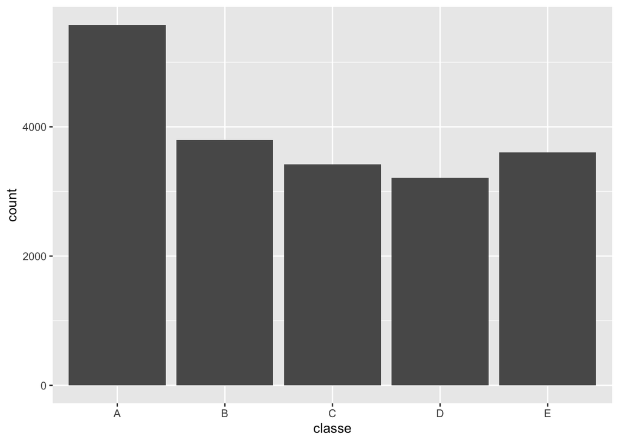

```r
library(ggplot2)
ggplot(dt.tr, aes(classe)) + geom_bar()
```

The training data is quite balanced among the 5 categories, with category A more abundant than the other categories.

The training dataset contains 159 variables that potentially can be used as predictors. It might be helpful to conduct exploratory analysis on these variables and select the ones that contain information to predict classe.

## Exploratory Analysis

### Near Zero Variance predictor

```r
library(lattice)
library(caret)
nsv <- nearZeroVar(dt.tr, saveMetrics = TRUE)
```

```r
var.sel <- rownames(nsv)[nsv$nzv == FALSE]
dt.tr2 <- dt.tr[, var.sel]
```

This step removes 60 near zero variance predictors.

It is also obvious the first variable X is row index. We shall remove this variable as well.

```r
dt.tr3 <- dt.tr2[, -1]
```

There are six users in the dataset:

```r
unique(dt.tr3$user_name)
```

```
## [1] "carlitos" "pedro"    "adelmo"   "charles"  "eurico"   "jeremy"
```

```r
table(dt.tr3$classe, dt.tr3$user_name)
```

```
##
##     adelmo carlitos charles eurico jeremy pedro
##   A   1165      834     899    865   1177   640
##   B    776      690     745    592    489   505
##   C    750      493     539    489    652   499
##   D    515      486     642    582    522   469
##   E    686      609     711    542    562   497
```

There are some timestamp columns in the dataset.

```r
dt.tr3$raw_timestamp_part_1 <- format(as.POSIXct(dt.tr3$raw_timestamp_part_1, origin = "1970-01-01", tz = ""))
dt.tr3$raw_timestamp_part_2 <-format(as.POSIXct(dt.tr3$raw_timestamp_part_2, origin = "1970-01-01", tz = ""), "%H:%M:%S")
```

```r
dt.tr3[1,c(1:3)]
```

```
##   user_name raw_timestamp_part_1 raw_timestamp_part_2
## 1  carlitos  2011-12-05 05:23:51             20:58:10
```

To make it simple, we remove the time data in the dataset.

```r
dt.tr4 <- dt.tr3[,c(7:ncol(dt.tr3))]
```

Also there are some columns that most of the observations are missing, this step removes the columns that have more than half of NAs

```r
dt.tr5 <- dt.tr4[,colSums(is.na(dt.tr4))/nrow(dt.tr4)<0.5]
```

Some variables are highly correlated. Here we identify the highly correlated variables.

```r
descrCorr <- cor(dt.tr5[,c(-ncol(dt.tr5))])
```

```r
highCorr <- findCorrelation(descrCorr, 0.90)
dt.tr6 <- dt.tr5[,-highCorr]

ncol(dt.tr6)
```

```
## [1] 46
```

Remove the variables that have correlation greater than 90%.

## Model training

To evaluate the performance of algorithm, the training data is further split to training and validation sets. Model is trained using training dataset, and model is evaluated using testing set.

```r
set.seed(1)
dt.tr6$classe <- as.factor(dt.tr6$classe)
inTrain <- createDataPartition(dt.tr6$classe, p = 3/4, list = FALSE)
training <- dt.tr6[inTrain,]
testing <- dt.tr6[-inTrain,]
```

Distribution of response variable classe are similar in the training and testing datasets.

```r
prop.table(table(training$classe))
```

```
##
##         A         B         C         D         E
## 0.2843457 0.1935046 0.1744123 0.1638810 0.1838565
```

```r
prop.table(table(dt.tr6$classe))
```

```
##
##         A         B         C         D         E
## 0.2843747 0.1935073 0.1743961 0.1638977 0.1838243
```

A simple way to build a model is use random forest algorithm. To speed up the training step, parallel computing is used with a cluster of 5 cpus.

```r
library(doParallel)
cl <- makePSOCKcluster(5)
registerDoParallel(cl)
modfit <- train(classe ~ ., data = training, method = "rf")
stopCluster(cl)
```

Prediction is done on the testing dataset for validation.

```r
pred <- predict(modfit, testing)
```

```r
testing$pred <- pred
```

```r
confusionMatrix(testing$pred, testing$classe)
```

```
## Confusion Matrix and Statistics
##
##           Reference
## Prediction    A    B    C    D    E
##          A 1391    6    0    0    0
##          B    4  942    7    0    0
##          C    0    1  845   15    1
##          D    0    0    3  789    5
##          E    0    0    0    0  895
##
## Overall Statistics
##
##                Accuracy : 0.9914
##                  95% CI : (0.9884, 0.9938)
##     No Information Rate : 0.2845
##     P-Value [Acc > NIR] : < 2.2e-16
##
##                   Kappa : 0.9892
##
##  Mcnemar's Test P-Value : NA
##
## Statistics by Class:
##
##                      Class: A Class: B Class: C Class: D Class: E
## Sensitivity            0.9971   0.9926   0.9883   0.9813   0.9933
## Specificity            0.9983   0.9972   0.9958   0.9980   1.0000
## Pos Pred Value         0.9957   0.9885   0.9803   0.9900   1.0000
## Neg Pred Value         0.9989   0.9982   0.9975   0.9963   0.9985
## Prevalence             0.2845   0.1935   0.1743   0.1639   0.1837
## Detection Rate         0.2836   0.1921   0.1723   0.1609   0.1825
## Detection Prevalence   0.2849   0.1943   0.1758   0.1625   0.1825
## Balanced Accuracy      0.9977   0.9949   0.9921   0.9897   0.9967
```

## Prediction

The predict classe for the dt.tst dataset, training is done using the all the observations of dt.tr as training set.

```r
cl <- makePSOCKcluster(5)
registerDoParallel(cl)
modfit2 <- train(classe ~ ., data = dt.tr6, method = "rf")
stopCluster(cl)
```

Subset the testing data frame with the same columns training set except response variable “classe”.

```r
col.sel <- names(dt.tr6)[-46]
col.sel <- c(col.sel, "problem_id")
dt.tst2 <- dt.tst[,col.sel]
```

```r
pred2 <- predict(modfit2, dt.tst2)
dt.tst2$pred <- as.character(pred2)
```

```r
dt.tst2[, c("problem_id", "pred")]
```

```
##    problem_id pred
## 1           1    B
## 2           2    A
## 3           3    B
## 4           4    A
## 5           5    A
## 6           6    E
## 7           7    D
## 8           8    B
## 9           9    A
## 10         10    A
## 11         11    B
## 12         12    C
## 13         13    B
## 14         14    A
## 15         15    E
## 16         16    E
## 17         17    A
## 18         18    B
## 19         19    B
## 20         20    B
```

Predicted values are shown as above.

## Reference

Velloso, E.; Bulling, A.; Gellersen, H.; Ugulino, W.; Fuks, H. Qualitative Activity Recognition of Weight Lifting Exercises. Proceedings of 4th International Conference in Cooperation with SIGCHI (Augmented Human ’13) . Stuttgart, Germany: ACM SIGCHI, 2013.

http://web.archive.org/web/20161224072740/http:/groupware.les.inf.puc-rio.br/har